# Lab-2: Vectors

Stat 33B

Author

Gaston Sanchez

**Learning Objectives**

- Work with vectors of different data types
- Understand the concept of *atomic* structures
- Learn how to subset and slice R vectors
- Understand the concept of *vectorization*
- Understand *recycling* rules in R

**General Instructions**

- Write your code and content in a `qmd` (quarto markdown) file. You can use the provided source `qmd` file (bCourses).
- Rename this file as `lab02-first-last.qmd`, where `first` and `last` are your first and last names (e.g. `lab02-gaston-sanchez.qmd`).
- Submit both your qmd and HTML files to the corresponding assignment submission in bCourses. This submission is just to make sure that everything works on your side.
- This lab does not count toward your final score.

# 1 Getting the Data File

In this lab, you are going to work with a handful of variables about NBA players from the regular season 2017-2018:

- `player`: name of player.
- `team`: team name abbreviation.
- `position`: player position.
- `age`: age of player.
- `experience`: years of experience in NBA.
- `salary`: salary (in dollars).
- `scored`: total scored points.
- `points1`: number of free throws, worth 1 point each.
- `points2`: number of 2-point field goals, worth 2 points each.
- `points3`: number of 3-point field goals, worth 3 points each.

The data is in the file `nba2018-salary-points.RData`, located in bCourses. See the folder containing this `qmd` of instructions.

Open a new session in Rstudio, and make sure you have a clean workspace by typing this command on the **console**:

```
# remove existing objects
rm(list = ls())
```

Download the `.RData` file to your working directory (or to your preferred location). We recommend that you have some filestructure like this (`first` and `last` refer to your first and last names):

```
stat33b/
   labs/
      lab01/
         lab01-first-last.qmd
      lab02/
         lab02-first-last.qmd
         nba2018-salary-points.RData
      lab03/
      ...
   hws/
      hw1/
      hw2/
      ...
   cheatsheets/
      ...
```

## 1.1 Loading the data file

To load or import the contents of the binary file into your R session you use `load()`. This function allows you to import R binary files. This time, include the code below in your `qmd` file:

```r
# load data in your R session
load('data/nba2018-salary-points.RData')
```

Once you imported (or loaded) the data, run `ls()` on the console to **list** all the available R objects in your workspace (*Global Environment*):

```r
# list the available objects with ls()
ls()
```

```
 [1] "age"             "experience"      "has_annotations" "player"
 [5] "points1"         "points2"         "points3"         "position"
 [9] "salary"          "scored"          "team"
```

# 2 Your Turn: Subsetting vectors

Create a vector `five` by selecting the first five elements in `player`:

```r
five <- head(player, n = 5)
```

Single brackets `[ ]` are used to subset (i.e. subscript, split) vectors. Find out what happens if you specify:

1. number one: `five[1]`

```r
# your code
five[1]
```

```
[1] "Al Horford"
```

2. an index of zero: `five[0]`?

```r
# your code
five[0]
```

```
character(0)
```

3. a negative index: `five[-1]`?

```r
# your code
five[-1]
```

```
[1] "Amir Johnson"      "Avery Bradley"     "Demetrius Jackson"
[4] "Gerald Green"
```

4. a sequence of consecutive integers: `five[1:3]`?

```r
# your code
five[1:3]
```

```
[1] "Al Horford"    "Amir Johnson"  "Avery Bradley"
```

5. various negative indices: `five[-c(1,2,3)]`?

```r
# your code
five[-c(1,2,3)]
```

```
[1] "Demetrius Jackson" "Gerald Green"
```

6. an index greater than the length of the vector: `five[6]`?

```r
# your code
five[6]
```

```
[1] NA
```

7. repeated indices: `five[c(1,2,2,3,3,3)]`?

```r
# your code
five[c(1,2,2,3,3,3)]
```

```
[1] "Al Horford"    "Amir Johnson"  "Amir Johnson"  "Avery Bradley"
[5] "Avery Bradley" "Avery Bradley"
```

Often, you will need to generate vectors of numeric sequences, like the first four elements `1:4`, or from the first till the last element `1:length(player)`. R provides the colon operator `:`, and the functions `seq()`, and `rep()` to create various types of sequences.

## 2.1 Your Turn: sequences and repetitions

Figure out how to use `seq()`, `rev()`, and bracket notation, to extract:

1. all the even elements in `player`

```r
# your code
player[seq(2, length(player), by = 2)]
```

```
  [1] "Amir Johnson"             "Demetrius Jackson"
  [3] "Isaiah Thomas"            "James Young"
  [5] "Jonas Jerebko"            "Kelly Olynyk"
  [7] "Terry Rozier"             "Andrew Bogut"
  [9] "Dahntay Jones"            "Derrick Williams"
 [11] "Iman Shumpert"            "James Jones"
 [13] "Kay Felder"               "Kyle Korver"
 [15] "Larry Sanders"            "Richard Jefferson"
 [17] "Bruno Caboclo"            "Delon Wright"
 [19] "DeMarre Carroll"          "Jakob Poeltl"
 [21] "Kyle Lowry"               "Norman Powell"
 [23] "Pascal Siakam"            "Serge Ibaka"
 [25] "Bradley Beal"             "Chris McCullough"
 [27] "Danuel House"             "Jason Smith"
 [29] "Kelly Oubre"              "Markieff Morris"
```

[output cut: 104 more lines]

2. all the odd elements in `salary`

```r
# your code
salary[seq(1, length(salary), by = 2)]
```

```
  [1] 26540100  8269663  1410598  6286408  4743000  1223653  3578880  8000000
  [9]  7806971   259626     5145 12800000   874636 21165675 17638063 30963450
 [17] 15330435  7330000 26540100   543471 14382022  1921320  5300000  6050000
 [25]  3730653  1200000   543471 15944154 16957900 12000000  5893981  3386598
 [33]  2708582  8400000   392478  4000000  2500000  1015696   418228  3850000
 [41]    51449  2995421  5374320 12517606   925000  1403611 10500000  6348759
 [49]   236457  2368327 10230179   650000  8800000  1800000  4000000  2463840
 [57]  1052342 14153652  1453680   874636 23200000  1643040  1709720  5782450
 [65]   425000 13219250 15890000  4000000   874636  1227000   543471  4000000
 [73]  1015696  6500000  7000000  1704120 10991957  4625000  2255644  2969880
 [81]   375579   231521  5318313  6511628 12000000 12250000   138938  6000000
 [89] 24559380 11242000 17000000  4317720  6191000   543471   543471  1375000
 [97]    51449 17000000  1209680   980431 17000000  6540000  3909840    31969
[105] 10000000  2318280   442126  9424084  1514160  2993040  1015696    96969
[113]  8550000  6088993   194494  1562280  1074145   980431  3333333  1914544
[121]  1395600   726672   202300 11131368  1551659  1015696  1403611  1182840
[129]   383351  5782450  2898000 10000000   543471  2898000   874636  1192080
[137] 14000000  3578948 14445313   543471 12385364 26540100  1045000  6000000
[145]  1720560   181969 11000000  1551659 22868827   543471 13253012  1403611
[153]  1551659 10154495  3940320  8000000  1015696 11000000   937800  2121288
[161]  2340600  2183072  2483040   980431  4837500   247991   543471  8950000
[169]   945000 22116750  2898000  1286160 26540100  5505618  4264057    83119
[177]  7680965  3219579  6666667   600000  8988764  2751360  1350120 15050000
[185]  3241800  3210840   150000 12078652  2328530  1358500  3533333  4600000
[193]   543471 16957900  8081363   234915  9904494    79922 11241218   650000
[201]  1015696 25000000  8375000  4096950   680937  4384490   105498  2898000
[209]  8000000  4008882  5229454  2202240  8046500  1439880  1188840 10661286
[217]  2022240  3500000  2348783  3911380  3872520 13550000  1339680  5281680
[225]  5332800  1034956  3267120  1551659  6191000 16000000   874636 12606250
[233]  2223600    23069 10470000   469841  2941440  2128920 12415000
```

3. all multiples of 5 (e.g. 5, 10, 15, etc) of `team`

```r
# your code
team[seq(5, length(team), by = 5)]
```

```
 [1] BOS BOS BOS CLE CLE CLE TOR TOR TOR WAS WAS WAS ATL ATL ATL ATL MIL MIL MIL
[20] IND IND IND IND CHI CHI CHI MIA MIA MIA DET DET DET CHO CHO CHO NYK NYK NYK
[39] ORL ORL ORL PHI PHI PHI PHI BRK BRK BRK BRK GSW GSW GSW SAS SAS SAS HOU HOU
[58] HOU LAC LAC LAC UTA UTA UTA OKC OKC OKC MEM MEM MEM POR POR POR DEN DEN DEN
[77] NOP NOP NOP DAL DAL DAL DAL SAC SAC SAC MIN MIN MIN LAL LAL LAL PHO PHO PHO
30 Levels: ATL BOS BRK CHI CHO CLE DAL DEN DET GSW HOU IND LAC LAL MEM ... WAS
```

4. elements in positions 10, 20, 30, 40, etc of `scored`

```r
# your code
scored[seq(10, length(scored), by = 10)]
```

```
 [1]  299  156    4  165 1779 1063  801 1143  577  322  630  291  538   98  127
[16] 1321  780 1154  124 1046   64  559 1539  357  776 1999 1888  818  936 1173
[31]  476  430   33   58  106  304  851    4    6    0    8  378  681 2061  120
[46]  170   24
```

5. all the even elements in `team` but this time in reverse order

```r
# your code
rev(team[seq(2, length(team), by = 2)])
```

```
  [1] PHO PHO PHO PHO PHO PHO PHO PHO LAL LAL LAL LAL LAL LAL LAL MIN MIN MIN
 [19] MIN MIN MIN MIN SAC SAC SAC SAC SAC SAC SAC SAC DAL DAL DAL DAL DAL DAL
 [37] DAL DAL DAL NOP NOP NOP NOP NOP NOP NOP NOP DEN DEN DEN DEN DEN DEN DEN
 [55] DEN DEN POR POR POR POR POR POR MEM MEM MEM MEM MEM MEM MEM MEM OKC OKC
 [73] OKC OKC OKC OKC OKC OKC UTA UTA UTA UTA UTA UTA UTA LAC LAC LAC LAC LAC
 [91] LAC LAC LAC HOU HOU HOU HOU HOU HOU HOU SAS SAS SAS SAS SAS SAS SAS SAS
[109] GSW GSW GSW GSW GSW GSW GSW GSW BRK BRK BRK BRK BRK BRK BRK BRK BRK PHI
[127] PHI PHI PHI PHI PHI PHI PHI PHI ORL ORL ORL ORL ORL ORL ORL ORL ORL NYK
[145] NYK NYK NYK NYK NYK NYK CHO CHO CHO CHO CHO CHO CHO CHO DET DET DET DET
[163] DET DET DET DET MIA MIA MIA MIA MIA MIA MIA CHI CHI CHI CHI CHI CHI CHI
[181] CHI IND IND IND IND IND IND IND IND MIL MIL MIL MIL MIL MIL MIL MIL MIL
[199] ATL ATL ATL ATL ATL ATL ATL ATL ATL WAS WAS WAS WAS WAS WAS WAS TOR TOR
[217] TOR TOR TOR TOR TOR TOR CLE CLE CLE CLE CLE CLE CLE CLE CLE BOS BOS BOS
[235] BOS BOS BOS BOS
30 Levels: ATL BOS BRK CHI CHO CLE DAL DEN DET GSW HOU IND LAC LAL MEM ... WAS
```

# 3 Logical Subsetting and Comparisons

Another kind of subsetting/subscripting is the so-called **logical subsetting**. This kind of subsetting typically takes place when making comparisons. A **comparison operation** occurs when you use comparison operators such as:

- `>` greater than
- `>=` greater than or equal
- `<` less than
- `<=` less than or equal
- `==` equal
- `!=` different

For example:

```r
scored_four <- scored[1:4]

# elements greater than 100
scored_four[scored_four > 100]
```

```
[1] 952 520 894
```

```r
# elements less than 100
scored_four[scored_four < 100]
```

```
[1] 10
```

```r
# elements less than or equal to 10
scored_four[scored_four <= 10]
```

```
[1] 10
```

```r
# elements different from 10
scored_four[scored_four != 10]
```

```
[1] 952 520 894
```

In addition to using comparison operators, you can also use **logical operators** to produce a logical vector. The most common type of logical operators are:

- `&` AND
- `|` OR
- `!` negation

Run the following commands to see what R does:

```r
# AND
TRUE & TRUE
```

```
[1] TRUE
```

```r
TRUE & FALSE
```

```
[1] FALSE
```

```r
FALSE & FALSE
```

```
[1] FALSE
```

```r
# OR
TRUE | TRUE
```

```
[1] TRUE
```

```r
TRUE | FALSE
```

```
[1] TRUE
```

```r
FALSE | FALSE
```

```
[1] FALSE
```

```r
# NOT
!TRUE
```

```
[1] FALSE
```

```r
!FALSE
```

```
[1] TRUE
```

Logical operators allow you to combine several comparisons:

```r
# players of Golden State (GSW)
player[team == 'GSW']

# name of players with salaries greater than 20 million dollars
player[salary > 20000000]

# name of players with scored points between 1000 and 1200 (exclusive)
player[scored > 1000 & points < 1200]
```

## 3.1 Your Turn: logical subsetting

Write commands, using bracket notation, to answer the following questions (you may need to use `min()`, `max()`, `which()`, `which.min()`, `which.max()`):

1. players in position Center (`C`), of Warriors (`GSW`)

```r
# your code
player[position == "C" & team == "GSW"]
```

```
[1] "Anderson Varejao" "Damian Jones"     "David West"       "JaVale McGee"
[5] "Kevon Looney"     "Zaza Pachulia"
```

2. players of both `GSW` (warriors) and `LAL` (lakers)

```r
# your code
player[team == "GSW" | team == "LAL"]
```

```
 [1] "Anderson Varejao"     "Andre Iguodala"       "Damian Jones"
 [4] "David West"           "Draymond Green"       "Ian Clark"
 [7] "James Michael McAdoo" "JaVale McGee"         "Kevin Durant"
[10] "Kevon Looney"         "Klay Thompson"        "Matt Barnes"
[13] "Patrick McCaw"        "Shaun Livingston"     "Stephen Curry"
[16] "Zaza Pachulia"        "Brandon Ingram"       "Corey Brewer"
[19] "D'Angelo Russell"     "David Nwaba"          "Ivica Zubac"
[22] "Jordan Clarkson"      "Julius Randle"        "Luol Deng"
[25] "Metta World Peace"    "Nick Young"           "Tarik Black"
[28] "Thomas Robinson"      "Timofey Mozgov"       "Tyler Ennis"
```

3. players in positions Shooting Guard (`SG`) and Point Guards (`PG`), of Lakers (`LAL`)

```r
# your code
player[team == "LAL" & position == "SG" | position == "PG"]
```

```
 [1] "Demetrius Jackson"       "Isaiah Thomas"
 [3] "Terry Rozier"            "Deron Williams"
 [5] "Kay Felder"              "Kyrie Irving"
 [7] "Cory Joseph"             "Delon Wright"
 [9] "Fred VanVleet"           "Kyle Lowry"
[11] "Brandon Jennings"        "John Wall"
[13] "Trey Burke"              "Dennis Schroder"
[15] "Jose Calderon"           "Malcolm Delaney"
[17] "Gary Payton"             "Matthew Dellavedova"
[19] "Aaron Brooks"            "Jeff Teague"
[21] "Joe Young"               "Rodney Stuckey"
[23] "Cameron Payne"           "Jerian Grant"
[25] "Michael Carter-Williams" "Rajon Rondo"
[27] "Goran Dragic"            "Tyler Johnson"
[29] "Beno Udrih"              "Ish Smith"
```

[output cut: 35 more lines]

4. subset Small Forwards (`SF`) of teams `GSW` and `LAL`

```r
# your code
player[position == "SF" & (team == "GSW" | team == "LAL")]
```

```
[1] "Andre Iguodala"    "Matt Barnes"       "Brandon Ingram"
[4] "Corey Brewer"      "Luol Deng"         "Metta World Peace"
```

5. name of the player with largest salary; *tip*: `which.max()` is your friend

```r
# your code
player[which.max(salary)]
```

```
[1] "LeBron James"
```

6. name of the player with smallest salary; *tip*: `which.min()` is your friend

```r
# your code
player[which.min(salary)]
```

```
[1] "Edy Tavares"
```

7. name of the player with largest number of scored points

```r
# your code
player[which.max(scored)]
```

```
[1] "Russell Westbrook"
```

8. largest salary of all Centers

```r
# your code
max(salary[position == "C"])
```

```
[1] 26540100
```

1. team of the player with the largest number of scored points

```r
# your code
team[which.max(scored)]
```

```
[1] OKC
30 Levels: ATL BOS BRK CHI CHO CLE DAL DEN DET GSW HOU IND LAC LAL MEM ... WAS
```

# 4 Some plotting

Use the function `plot()` to make a scatterplot of `scored` and `salary`

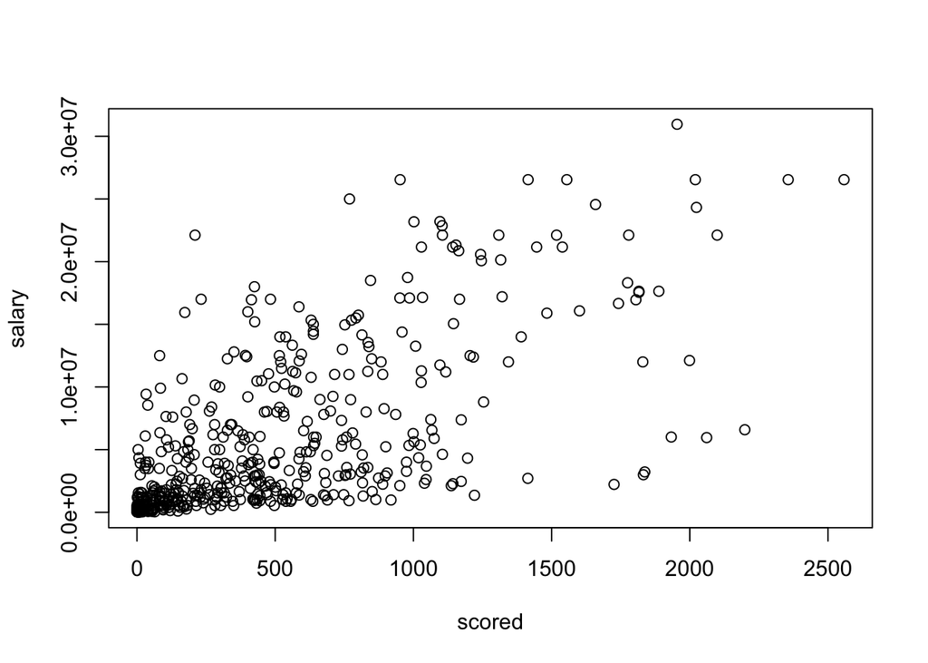

```r
plot(scored, salary)
```

Keep in mind that `plot()` is a generic function. This means that the behavior of `plot()` depends on the type of input. When you pass two numeric vectors, `plot()` will attempt to create a scatter plot.

## 4.1 Your Turn: Log-transformed scales

Looking at the generated plot, can you see any issues? To get a better display of the scatterplot, let’s create two vectors `log_scored` and `log_salary` by transforming `scored` and `salary` with the logarithm function `log()`

```r
log_scored <- log(scored)
log_salary <- log(salary)
```

1. Make another scatterplot but now use the log-transformed vectors:

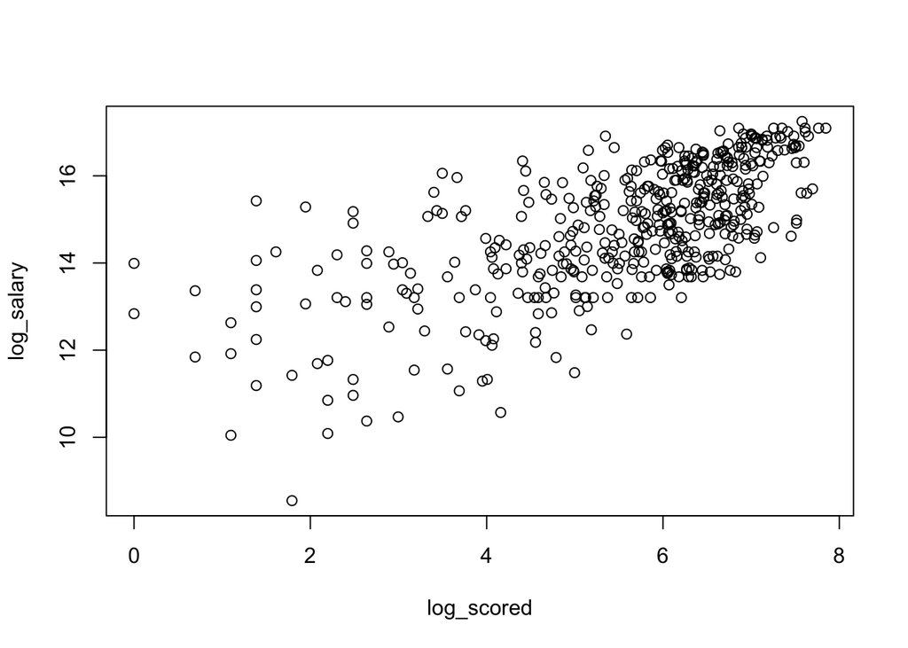

```r
# your code
plot(log_scored, log_salary)
```

## 4.2 Your Turn: Adding text

1. Take `scored`, `salary`, and `player`, and use logical subsetting to create the following vectors for Golden State Warriors `GSW`:
   - `gsw_scored`
   - `gsw_salary`
   - `gsw_player`

```r
# your code
gsw_scored <- scored[team == "GSW"]
gsw_salary <- salary[team == "GSW"]
gsw_player <- player[team == "GSW"]
```

2. Make a scatterplot of `gsw_scored` and `gsw_salary`, and then use the low-level graphing function `text()` to add player names. This function—`text()`— needs the same x-y coordinates of `plot()` and a `labels` argument. Pass `gsw_player` to the argument `labels`:

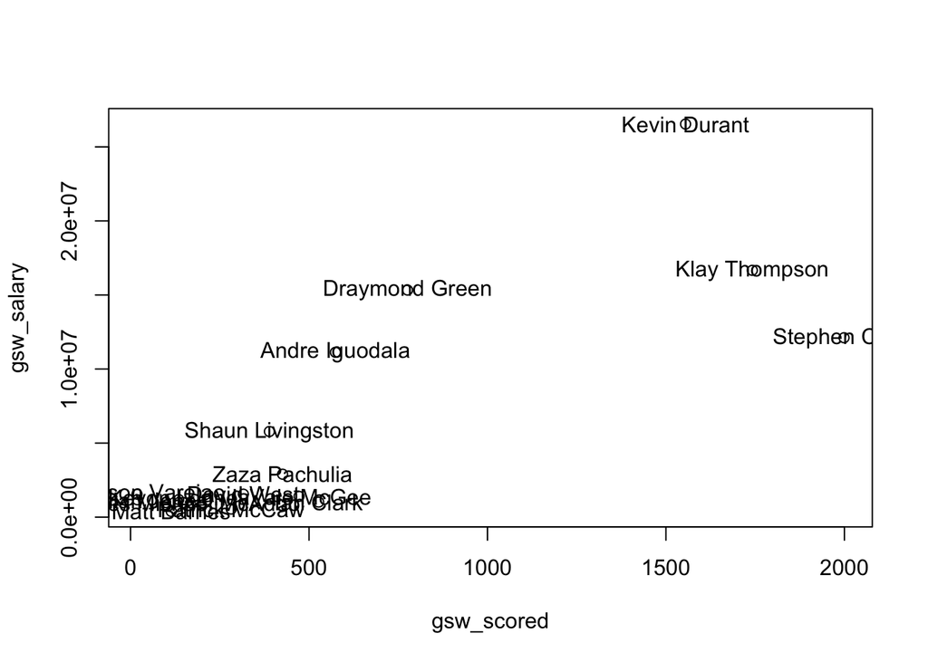

```r
# your code
plot(gsw_scored, gsw_salary)
text(gsw_scored, gsw_salary, labels = gsw_player)
```

## 4.3 Your Turn: More Plots

See the documentation of the following functions and use them to create various plots. Feel free to play with the arguments of the functions.

1. `boxplot()`: boxplot of `age`

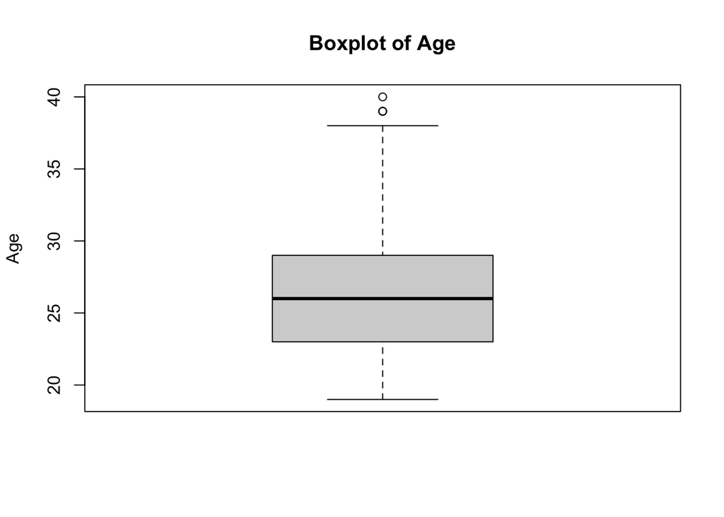

```r
# your code
boxplot(age, main = "Boxplot of Age", ylab = "Age")
```

2. `hist()`: histogram of `experience` (replace `"R"` with `0`, and coerce `experience` into a numeric vector with `as.numeric()`)

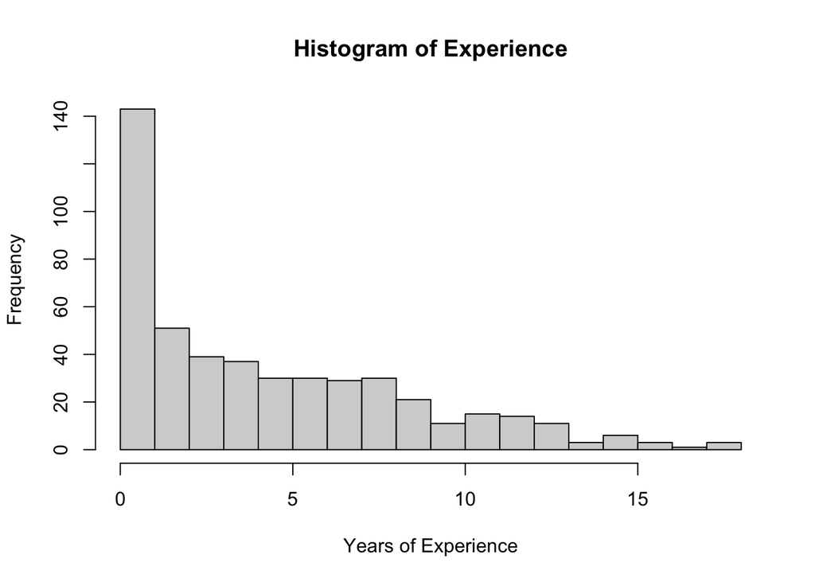

```r
# your code
experience[experience == "R"] <- 0
experience_numeric <- as.numeric(experience)
hist(experience_numeric, main="Histogram of Experience", xlab="Years of Experience", breaks=20)
```

3. `barplot()`: barchart of `position`; first use `table()` to get frequencies and then pass them to `barplot()`

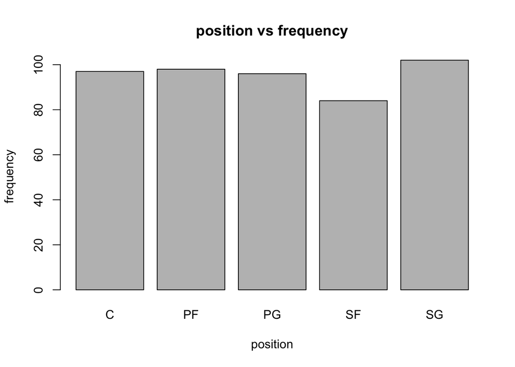

```r
# your code
position_freq <- table(position)
barplot(position_freq, xlab="position", ylab="frequency", main="position vs frequency")
```